# Answers 5.2 and 5.3

causal inference1. propensity score methods

# 5.2 Propensity score weighting

Read data and load packages

```r
# read data
load("rhc_exercise.Rdata")
library("cobalt")
library("survey")
```

1. Fit the propensity model with all covarites except surv2md1 and aps1. Examine the output.

```r
PS1.model<-glm(treatment~ transhx + age +
    scoma1 + hrt1 + bili1 + wtkilo1 + cat1, family = binomial,
    data = rhc)
summary(PS1.model)
```

```
##
## Call:
## glm(formula = treatment ~ transhx + age + scoma1 + hrt1 + bili1 +
##     wtkilo1 + cat1, family = binomial, data = rhc)
##
## Coefficients:
##                         Estimate Std. Error z value Pr(>|z|)
## (Intercept)           -1.9073406  0.1967016  -9.697  < 2e-16 ***
## transhx                0.5426888  0.0875449   6.199 5.68e-10 ***
## age                    0.0032199  0.0017884   1.800  0.07179 .
## scoma1                -0.0019473  0.0011566  -1.684  0.09224 .
## hrt1                   0.0028841  0.0007398   3.899 9.67e-05 ***
## bili1                  0.0267466  0.0061889   4.322 1.55e-05 ***
## wtkilo1                0.0098138  0.0013141   7.468 8.13e-14 ***
## cat1CHF                0.3973320  0.1064659   3.732  0.00019 ***
## cat1COPD              -1.3804068  0.1485325  -9.294  < 2e-16 ***
## cat1Cirrhosis         -0.9184740  0.1743862  -5.267 1.39e-07 ***
## cat1Colon Cancer      -1.1519303  1.0871074  -1.060  0.28931
## cat1Coma              -0.5785267  0.1429332  -4.048 5.18e-05 ***
## cat1Lung Cancer       -1.2690193  0.4826942  -2.629  0.00856 **
## cat1MOSF w/Malignancy  0.0984301  0.1127698   0.873  0.38275
## cat1MOSF w/Sepsis      0.7993355  0.0727869  10.982  < 2e-16 ***
## ---
## Signif. codes:  0 '***' 0.001 '**' 0.01 '*' 0.05 '.' 0.1 ' ' 1
##
## (Dispersion parameter for binomial family taken to be 1)
##
##     Null deviance: 7621.4  on 5734  degrees of freedom
## Residual deviance: 7049.6  on 5720  degrees of freedom
## AIC: 7079.6
##
## Number of Fisher Scoring iterations: 4
```

2. Generate a new variable called ps1 that holds the predicted values of the propensity of receiving RHC derived from the model fitted in a.. Explore the propensity score.

```r
# Calculate propensity
rhc$ps1<-fitted.values(PS1.model)
# explore propensity
summary(rhc$ps1)
```

```
##    Min. 1st Qu.  Median    Mean 3rd Qu.    Max.
## 0.06782 0.29202 0.37140 0.38082 0.48347 0.89477
```

The minimum propensity value (= the probability to receive RHC) is 0.07, the maximum is 0.89.

Generate the corresponding weights ipw1 (remember that weights depend on the exposure status of each individual);

```r
rhc$ipw1 <- (rhc$treatment=="RHC")/rhc$ps1+(rhc$treatment=="no RHC")/(1-rhc$ps1)
summary(rhc$ipw1)
```

```
##    Min. 1st Qu.  Median    Mean 3rd Qu.    Max.
##   1.073   1.443   1.706   2.003   2.263  12.732
```

3. Examine whether the covariates are balanced between the two treatment groups, first as they are and then after reweighing the observations according to ipw1. You can check for balance as follows. First define a new data frame named covariates with all variables for which you would like to asses balance:

```r
vars1 <- c("transhx","age","scoma1","hrt1","bili1","wtkilo1","cat1",
"surv2md1","aps1")
covariates <-rhc[, vars1]
```

Calculate standardized differences between the treated and untreated patients:

```r
  bal.tab(covariates, treat = rhc$treatment, weights = rhc$ipw1, method = "weighting", un=TRUE)
```

```
## Note: `s.d.denom` not specified; assuming "pooled".
```

```
## Balance Measures
##                           Type Diff.Un Diff.Adj
## transhx                 Binary  0.0554   0.0007
## age                    Contin. -0.0614   0.0005
## scoma1                 Contin. -0.1098   0.0227
## hrt1                   Contin.  0.1469  -0.0164
## bili1                  Contin.  0.1446  -0.0075
## wtkilo1                Contin.  0.2256  -0.0012
## cat1_ARF                Binary -0.0290  -0.0040
## cat1_CHF                Binary  0.0261   0.0000
## cat1_COPD               Binary -0.0858   0.0002
## cat1_Cirrhosis          Binary -0.0268   0.0001
## cat1_Colon Cancer       Binary -0.0012   0.0000
## cat1_Coma               Binary -0.0525   0.0057
## cat1_Lung Cancer        Binary -0.0073  -0.0003
## cat1_MOSF w/Malignancy  Binary  0.0045  -0.0008
## cat1_MOSF w/Sepsis      Binary  0.1721  -0.0010
## surv2md1               Contin. -0.1985  -0.2997
## aps1                   Contin.  0.5014   0.4165
##
## Effective sample sizes
##             no RHC     RHC
## Unadjusted 3551.   2184.
## Adjusted   3297.72 1738.58
```

and a “Love-plot”

```
## Note: `s.d.denom` not specified; assuming "pooled".
```

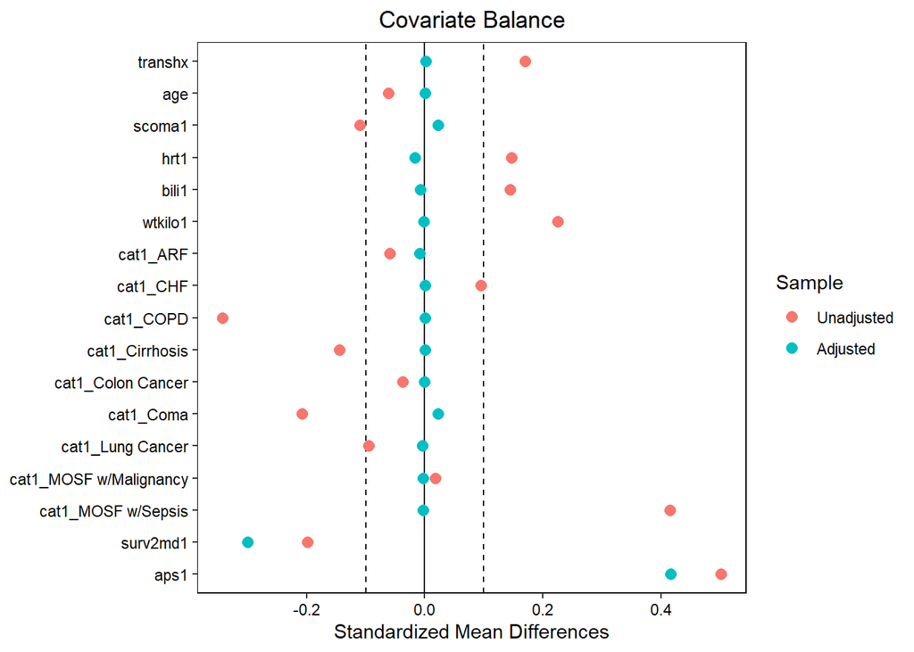

```r
love.plot(covariates, treat = rhc$treatment, weights = rhc$ipw1,method = "weighting",   binary = "std", threshold = .1)
```

Examining the distribution of all the available variables we first notice great imbalances across the two treatment groups(red dots). However their distributions becomes balanced after re-weighting with ipw1, with the exception of the distribution of surv2md1 and aps1, where the standardized difference is much higher than 0.1.

4. Add the two remaining variables to your propensity model: surv2md1 and aps1. Generate a new variable ps2 that holds the predicted values of the propensity of receiving RHC. Calculate the minimum and maximum of ps2 . Also examine the distribution of ps2 , by making a histogram separately for the two treatment What can you conclude about the positivity assumption?

```r
#PS-MODEL 2
PS2.model<-glm(treatment~ transhx + age +
    scoma1 + hrt1 + bili1 + wtkilo1 + cat1+surv2md1+aps1, family = binomial,
    data = rhc)
summary(PS2.model)
```

```
##
## Call:
## glm(formula = treatment ~ transhx + age + scoma1 + hrt1 + bili1 +
##     wtkilo1 + cat1 + surv2md1 + aps1, family = binomial, data = rhc)
##
## Coefficients:
##                         Estimate Std. Error z value Pr(>|z|)
## (Intercept)           -1.0372749  0.3362492  -3.085  0.00204 **
## transhx                0.6860904  0.0904192   7.588 3.25e-14 ***
## age                   -0.0051040  0.0020279  -2.517  0.01184 *
## scoma1                -0.0068209  0.0013238  -5.153 2.57e-07 ***
## hrt1                   0.0014886  0.0007586   1.962  0.04973 *
## bili1                 -0.0002230  0.0063827  -0.035  0.97213
## wtkilo1                0.0109611  0.0013536   8.098 5.60e-16 ***
## cat1CHF                0.9062462  0.1146630   7.904 2.71e-15 ***
## cat1COPD              -1.0939852  0.1519484  -7.200 6.03e-13 ***
## cat1Cirrhosis         -0.9407151  0.1779204  -5.287 1.24e-07 ***
## cat1Colon Cancer      -1.0907678  1.1049168  -0.987  0.32355
## cat1Coma              -0.7041024  0.1532261  -4.595 4.32e-06 ***
## cat1Lung Cancer       -1.1897262  0.4922679  -2.417  0.01566 *
## cat1MOSF w/Malignancy -0.6373686  0.1340213  -4.756 1.98e-06 ***
## cat1MOSF w/Sepsis      0.6492980  0.0754932   8.601  < 2e-16 ***
## surv2md1              -1.8602550  0.2608313  -7.132 9.89e-13 ***
## aps1                   0.0177368  0.0019704   9.002  < 2e-16 ***
## ---
## Signif. codes:  0 '***' 0.001 '**' 0.01 '*' 0.05 '.' 0.1 ' ' 1
##
## (Dispersion parameter for binomial family taken to be 1)
##
##     Null deviance: 7621.4  on 5734  degrees of freedom
## Residual deviance: 6779.1  on 5718  degrees of freedom
## AIC: 6813.1
##
## Number of Fisher Scoring iterations: 4
```

```r
# Calculate propensity
rhc$ps2<-fitted.values(PS2.model)
# explore propensity
summary(rhc$ps2)
```

```
##    Min. 1st Qu.  Median    Mean 3rd Qu.    Max.
## 0.03975 0.24215 0.36314 0.38082 0.51358 0.96591
```

The new propensity model shows that the additional variables surv2md1 and aps1 are strongly associated with treatment received:

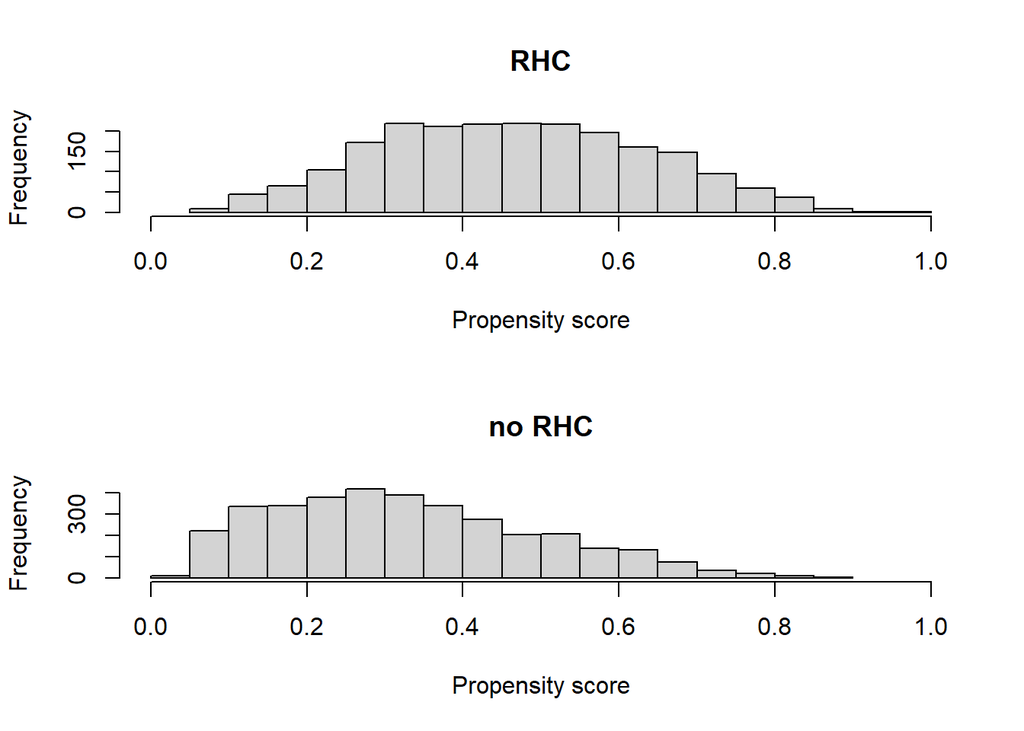

```r
# histogram
par(mfrow=c(2,1))
hist(rhc$ps2[rhc$treatment == "RHC"], xlim=c(0,1),main="RHC", xlab="Propensity score")
hist(rhc$ps2[rhc$treatment == "no RHC"], xlim=c(0,1),main="no RHC", xlab="Propensity score")
```

The minimum propensity value is 0.04, the maximum is 0.97. This indicates that there are no individuals for which the propensity score P(X=1|C) is 0 or 1, suggesting that the positivity assumption holds. The histograms also show considerable overlap.

5. Use the ps2 values to create the corresponding weights, ipw2. Check the covariate balance across treatment groups after weighing the two treatment groups using these new weights.

```r
rhc$ipw2 <- (rhc$treatment=="RHC")/rhc$ps2 + (rhc$treatment=="no RHC")/(1-rhc$ps2)
summary(rhc$ipw2)
```

```
##    Min. 1st Qu.  Median    Mean 3rd Qu.    Max.
##   1.035   1.340   1.643   1.985   2.240  15.452
```

```r
# check for balance
bal.tab(covariates, treat = rhc$treatment, weights = rhc$ipw2,method = "weighting", un=TRUE)
```

```
## Note: `s.d.denom` not specified; assuming "pooled".
```

```
## Balance Measures
##                           Type Diff.Un Diff.Adj
## transhx                 Binary  0.0554   0.0018
## age                    Contin. -0.0614  -0.0023
## scoma1                 Contin. -0.1098  -0.0034
## hrt1                   Contin.  0.1469   0.0150
## bili1                  Contin.  0.1446   0.0060
## wtkilo1                Contin.  0.2256   0.0045
## cat1_ARF                Binary -0.0290   0.0061
## cat1_CHF                Binary  0.0261   0.0034
## cat1_COPD               Binary -0.0858  -0.0088
## cat1_Cirrhosis          Binary -0.0268  -0.0022
## cat1_Colon Cancer       Binary -0.0012   0.0001
## cat1_Coma               Binary -0.0525  -0.0055
## cat1_Lung Cancer        Binary -0.0073  -0.0014
## cat1_MOSF w/Malignancy  Binary  0.0045   0.0036
## cat1_MOSF w/Sepsis      Binary  0.1721   0.0047
## surv2md1               Contin. -0.1985  -0.0187
## aps1                   Contin.  0.5014   0.0235
##
## Effective sample sizes
##             no RHC     RHC
## Unadjusted 3551.   2184.
## Adjusted   3116.93 1680.32
```

```
## Note: `s.d.denom` not specified; assuming "pooled".
```

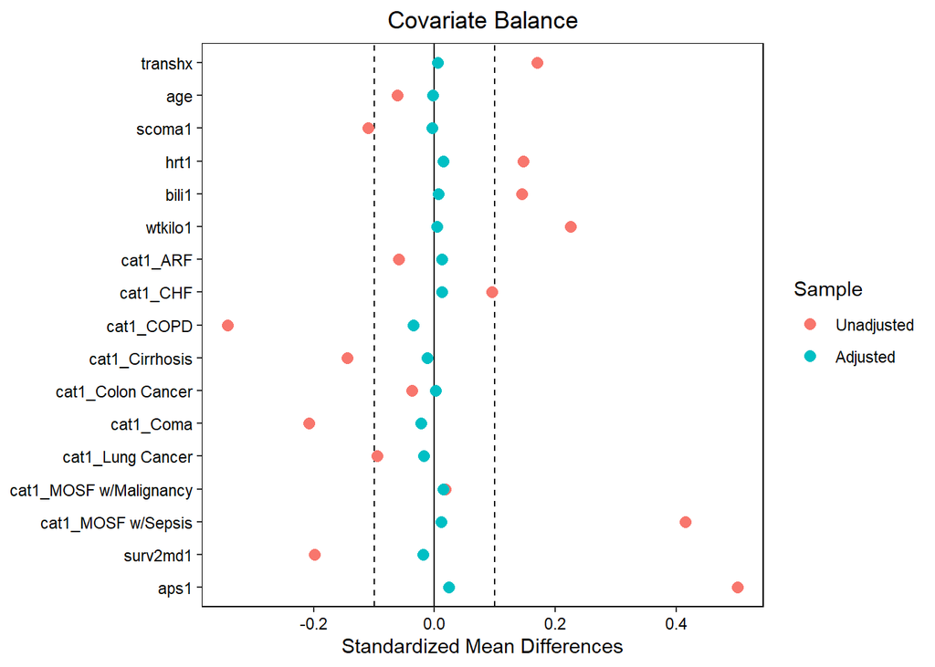

```r
#plot
love.plot(covariates, treat = rhc$treatment, weights = rhc$ipw2,method = "weighting",
          binary = "std", threshold = .1)
```

The distribution of all variables becomes balanced after re-weighting

f.Recode death30 into a 0/1 variable

```r
# Make a 1/0 variable of the factor variable rch$death30 (1=death, 0 is alive)
table(rhc$death30 )
```

```
##
## alive death
##  3817  1918
```

```r
table(as.numeric(rhc$death30 ))
```

```
##
##    1    2
## 3817 1918
```

```r
rhc$death30.num <- as.numeric(rhc$death30)-1
table(rhc$death30.num)
```

```
##
##    0    1
## 3817 1918
```

7. Calculate the weighted mean outcome in the treatment group, in the untreated group and calculate the ATE

```r
# weighted mean outcome in the treated
mean1.ipw <-weighted.mean(rhc$death30.num[rhc$treatment=="RHC"], w=rhc$ipw2[rhc$treatment=="RHC"])
mean1.ipw
```

```
## [1] 0.3579926
```

```r
 # weighted mean outcome in the untreated
mean0.ipw <-weighted.mean(rhc$death30.num[rhc$treatment=="no RHC"], w=rhc$ipw2[rhc$treatment=="no RHC"])
mean0.ipw
```

```
## [1] 0.3207336
```

```r
# estimate of ATE
mean1.ipw-mean0.ipw
```

```
## [1] 0.03725898
```

8. Calculate the 95% Confidence Interval for the ATE.

```r
# Use the package survey (install if not installed)
library(survey)
# standard errors, using survey package, and a linear model
# to estimate the difference between the two groups
# Calculate ATE with robust Standard errors
d.w <- svydesign(~1, weights = rhc$ipw2, data = rhc)
fit.ipw <- svyglm(death30.num ~ treatment, design = d.w)
summary(fit.ipw)
```

```
##
## Call:
## svyglm(formula = death30.num ~ treatment, design = d.w)
##
## Survey design:
## svydesign(~1, weights = rhc$ipw2, data = rhc)
##
## Coefficients:
##              Estimate Std. Error t value Pr(>|t|)
## (Intercept)   0.32073    0.00851  37.689  < 2e-16 ***
## treatmentRHC  0.03726    0.01432   2.602  0.00929 **
## ---
## Signif. codes:  0 '***' 0.001 '**' 0.01 '*' 0.05 '.' 0.1 ' ' 1
##
## (Dispersion parameter for gaussian family taken to be 0.2238068)
##
## Number of Fisher Scoring iterations: 2
```

```r
# 95% CI
confint(fit.ipw)
```

```
##                    2.5 %    97.5 %
## (Intercept)  0.304050792 0.3374165
## treatmentRHC 0.009187664 0.0653303
```

The regression coefficient for treatment 0.037 is the estimate of the ATE and the 95% confidence interval is (0.009, 0.065).

1. Explore the weights, calculate the minimum and maximum values. Do you see any very large values? What would happen if there are very large weights?

```r
summary(rhc$ipw2)
```

```
##    Min. 1st Qu.  Median    Mean 3rd Qu.    Max.
##   1.035   1.340   1.643   1.985   2.240  15.452
```

The minimum weight is 1.04, the maximum is 15.45. This indicates that some observation have a relatively high impact to the results. If weights are very large, they are usually being truncated.

10. Calculate truncated weights, truncated at the 99 th percentile. and calculate a new ATE

```r
# the 99 th percentile is
ipw2.p99 <-quantile(rhc$ipw2,0.99)
ipw2.p99
```

```
##      99%
## 6.605993
```

```r
rhc$ipw2.trunc <- ifelse(rhc$ipw2>ipw2.p99, ipw2.p99, rhc$ipw2)

summary(rhc$ipw2.trunc)
```

```
##    Min. 1st Qu.  Median    Mean 3rd Qu.    Max.
##   1.035   1.340   1.643   1.965   2.240   6.606
```

```r
# and calculate the ATE with the truncated weights

d.w.trunc <- svydesign(~1, weights = rhc$ipw2.trunc, data = rhc)
fit.ipw.trunc <- svyglm(death30.num ~ treatment, design = d.w.trunc)
summary(fit.ipw.trunc)
```

```
##
## Call:
## svyglm(formula = death30.num ~ treatment, design = d.w.trunc)
##
## Survey design:
## svydesign(~1, weights = rhc$ipw2.trunc, data = rhc)
##
## Coefficients:
##              Estimate Std. Error t value Pr(>|t|)
## (Intercept)  0.320772   0.008496  37.754  < 2e-16 ***
## treatmentRHC 0.038854   0.014060   2.763  0.00574 **
## ---
## Signif. codes:  0 '***' 0.001 '**' 0.01 '*' 0.05 '.' 0.1 ' ' 1
##
## (Dispersion parameter for gaussian family taken to be 0.2239813)
##
## Number of Fisher Scoring iterations: 2
```

The estimated ATE with truncated wights is 0.039 is the estimate of the ATE and the 95% confidence interval is (0.011, 0.066). Very similar to the untruncated results.

# 5.3 Matching

```r
library(MatchIt)
```

Matching using matchit

```r
# 1:1 NN PS matching without replacement
match.out1 <- matchit(treatment ~ transhx + age + scoma1 + hrt1 + bili1 +
    wtkilo1 + cat1 + surv2md1 + aps1, data=rhc,
                 method = "nearest", distance = "glm")

match.out1
```

```
## A matchit object
##  - method: 1:1 nearest neighbor matching without replacement
##  - distance: Propensity score
##              - estimated with logistic regression
##  - number of obs.: 5735 (original), 4368 (matched)
##  - target estimand: ATT
##  - covariates: transhx, age, scoma1, hrt1, bili1, wtkilo1, cat1, surv2md1, aps1
```

```r
summary(match.out1)
```

```
##
## Call:
## matchit(formula = treatment ~ transhx + age + scoma1 + hrt1 +
##     bili1 + wtkilo1 + cat1 + surv2md1 + aps1, data = rhc, method = "nearest",
##     distance = "glm")
##
## Summary of Balance for All Data:
##                       Means Treated Means Control Std. Mean Diff. Var. Ratio
## distance                     0.4658        0.3286          0.8097     1.0208
## transhx                      0.1497        0.0943          0.1552          .
## age                         60.7498       61.7609         -0.0647     0.8175
## scoma1                      18.9734       22.2532         -0.1160     0.8116
## hrt1                       118.9281      112.8730          0.1460     1.0260
## bili1                        2.7057        1.9973          0.1329     1.4504
## wtkilo1                     78.2336       73.2753          0.2298     0.9297
## cat1ARF                      0.4162        0.4452         -0.0589          .
## cat1CHF                      0.0957        0.0696          0.0889          .
## cat1COPD                     0.0266        0.1124         -0.5337          .
## cat1Cirrhosis                0.0224        0.0493         -0.1813          .
## cat1Colon Cancer             0.0005        0.0017         -0.0576          .
## cat1Coma                     0.0435        0.0960         -0.2575          .
## cat1Lung Cancer              0.0023        0.0096         -0.1524          .
## cat1MOSF w/Malignancy        0.0723        0.0679          0.0173          .
## cat1MOSF w/Sepsis            0.3205        0.1484          0.3688          .
## surv2md1                     0.5685        0.6072         -0.1954     1.0663
## aps1                        60.7390       50.9335          0.4837     1.1609
##                       eCDF Mean eCDF Max
## distance                 0.2181   0.3183
## transhx                  0.0554   0.0554
## age                      0.0285   0.0703
## scoma1                   0.0346   0.0683
## hrt1                     0.0344   0.0782
## bili1                    0.0244   0.1119
## wtkilo1                  0.0535   0.1252
## cat1ARF                  0.0290   0.0290
## cat1CHF                  0.0261   0.0261
## cat1COPD                 0.0858   0.0858
## cat1Cirrhosis            0.0268   0.0268
## cat1Colon Cancer         0.0012   0.0012
## cat1Coma                 0.0525   0.0525
```

[output cut: 37 more lines]

```
## cat1Cirrhosis            0.0046   0.0046          0.3154
## cat1Colon Cancer         0.0005   0.0005          0.0214
## cat1Coma                 0.0032   0.0032          0.4108
## cat1Lung Cancer          0.0009   0.0009          0.0766
## cat1MOSF w/Malignancy    0.0060   0.0060          0.5355
## cat1MOSF w/Sepsis        0.0865   0.0865          0.6387
## surv2md1                 0.0228   0.0582          1.1004
## aps1                     0.0320   0.0966          0.9154
##
## Sample Sizes:
##           Control Treated
## All          3551    2184
## Matched      2184    2184
## Unmatched    1367       0
## Discarded       0       0
```

3. Matching using a caliper

```r
match.out2 <- matchit(treatment ~ transhx + age + scoma1 + hrt1 + bili1 +
    wtkilo1 + cat1 + surv2md1 + aps1, data=rhc,
                 method = "nearest", distance = "glm", caliper=0.1)

match.out2
```

```
## A matchit object
##  - method: 1:1 nearest neighbor matching without replacement
##  - distance: Propensity score [caliper]
##              - estimated with logistic regression
##  - caliper: <distance> (0.018)
##  - number of obs.: 5735 (original), 3892 (matched)
##  - target estimand: ATT
##  - covariates: transhx, age, scoma1, hrt1, bili1, wtkilo1, cat1, surv2md1, aps1
```

```r
summary(match.out2)
```

```
##
## Call:
## matchit(formula = treatment ~ transhx + age + scoma1 + hrt1 +
##     bili1 + wtkilo1 + cat1 + surv2md1 + aps1, data = rhc, method = "nearest",
##     distance = "glm", caliper = 0.1)
##
## Summary of Balance for All Data:
##                       Means Treated Means Control Std. Mean Diff. Var. Ratio
## distance                     0.4658        0.3286          0.8097     1.0208
## transhx                      0.1497        0.0943          0.1552          .
## age                         60.7498       61.7609         -0.0647     0.8175
## scoma1                      18.9734       22.2532         -0.1160     0.8116
## hrt1                       118.9281      112.8730          0.1460     1.0260
## bili1                        2.7057        1.9973          0.1329     1.4504
## wtkilo1                     78.2336       73.2753          0.2298     0.9297
## cat1ARF                      0.4162        0.4452         -0.0589          .
## cat1CHF                      0.0957        0.0696          0.0889          .
## cat1COPD                     0.0266        0.1124         -0.5337          .
## cat1Cirrhosis                0.0224        0.0493         -0.1813          .
## cat1Colon Cancer             0.0005        0.0017         -0.0576          .
## cat1Coma                     0.0435        0.0960         -0.2575          .
## cat1Lung Cancer              0.0023        0.0096         -0.1524          .
## cat1MOSF w/Malignancy        0.0723        0.0679          0.0173          .
## cat1MOSF w/Sepsis            0.3205        0.1484          0.3688          .
## surv2md1                     0.5685        0.6072         -0.1954     1.0663
## aps1                        60.7390       50.9335          0.4837     1.1609
##                       eCDF Mean eCDF Max
## distance                 0.2181   0.3183
## transhx                  0.0554   0.0554
## age                      0.0285   0.0703
## scoma1                   0.0346   0.0683
## hrt1                     0.0344   0.0782
## bili1                    0.0244   0.1119
## wtkilo1                  0.0535   0.1252
## cat1ARF                  0.0290   0.0290
## cat1CHF                  0.0261   0.0261
## cat1COPD                 0.0858   0.0858
## cat1Cirrhosis            0.0268   0.0268
## cat1Colon Cancer         0.0012   0.0012
## cat1Coma                 0.0525   0.0525
```

[output cut: 37 more lines]

```
## cat1Cirrhosis            0.0021   0.0021          0.3331
## cat1Colon Cancer         0.0005   0.0005          0.0240
## cat1Coma                 0.0010   0.0010          0.4434
## cat1Lung Cancer          0.0010   0.0010          0.0860
## cat1MOSF w/Malignancy    0.0021   0.0021          0.5554
## cat1MOSF w/Sepsis        0.0329   0.0329          0.6166
## surv2md1                 0.0128   0.0391          1.0847
## aps1                     0.0094   0.0344          0.8948
##
## Sample Sizes:
##           Control Treated
## All          3551    2184
## Matched      1946    1946
## Unmatched    1605     238
## Discarded       0       0
```

There is more balance, but this is at the expense of the number of observations that have been matched.

```r
match.data <- match.data(match.out2)

View(match.data)
```

```r
table(match.data$treatment, match.data$death30)
```

```
##
##          alive death
##   no RHC  1308   638
##   RHC     1231   715
```

```r
tab<- prop.table(table(match.data$treatment, match.data$death30) , margin=1)
tab
```

```
##
##              alive     death
##   no RHC 0.6721480 0.3278520
##   RHC    0.6325797 0.3674203
```

36.7 % of the patients in the matched dataset who received RHC and 32.8% of the patients who did not receive RHC died within 30 days. A difference of 4 percent pounts